# Exploratory Data Analysis: White Wine Quality

Josh Lovelace

Welcome to my exploration of the White Wine Quality data set. The data details twelve variables over nearly five thousand observations of different white wines. The wines are numbered rather than named, and the ‘quality’ variable reflects the subjective rating by a panel of experts on a 0-10 scale. The remaining eleven variables are objective measurements of the chemical characteristics of the wine.

This project was created as part of a Udacity assignment to demonstrate facility with R exploratory data analysis.

# Univariate Exploration & Analysis

### Getting to Know our Data

Let’s take our first look at our dataframe.

```
## 'data.frame':    4898 obs. of  13 variables:
##  $ X                   : int  1 2 3 4 5 6 7 8 9 10 ...
##  $ fixed.acidity       : num  7 6.3 8.1 7.2 7.2 8.1 6.2 7 6.3 8.1 ...
##  $ volatile.acidity    : num  0.27 0.3 0.28 0.23 0.23 0.28 0.32 0.27 0.3 0.22 ...
##  $ citric.acid         : num  0.36 0.34 0.4 0.32 0.32 0.4 0.16 0.36 0.34 0.43 ...
##  $ residual.sugar      : num  20.7 1.6 6.9 8.5 8.5 6.9 7 20.7 1.6 1.5 ...
##  $ chlorides           : num  0.045 0.049 0.05 0.058 0.058 0.05 0.045 0.045 0.049 0.044 ...
##  $ free.sulfur.dioxide : num  45 14 30 47 47 30 30 45 14 28 ...
##  $ total.sulfur.dioxide: num  170 132 97 186 186 97 136 170 132 129 ...
##  $ density             : num  1.001 0.994 0.995 0.996 0.996 ...
##  $ pH                  : num  3 3.3 3.26 3.19 3.19 3.26 3.18 3 3.3 3.22 ...
##  $ sulphates           : num  0.45 0.49 0.44 0.4 0.4 0.44 0.47 0.45 0.49 0.45 ...
##  $ alcohol             : num  8.8 9.5 10.1 9.9 9.9 10.1 9.6 8.8 9.5 11 ...
##  $ quality             : int  6 6 6 6 6 6 6 6 6 6 ...
```

One may immediately notice that our variables are entirely numeric. Given that each variable is a real measurement excepting ‘quality’ (a subjective score represented by an integer, in reality an ordered factor) and ‘X’ (a simple identification integer tag for each wine observation), this is unsurprising. In fact, having many continuous variables will allow for the construction of a very robust linear model later in the project.

Given the structure of our data, our eventual analysis is clear - we may create a model for white wine that explains the subjective scoring by experts (the dependent variable) using our various measurements (the independent variables).

### Histograms

In this section, we will be familiarizing ourselves with the data through examination of histograms and simple summaries that include minima, maxima, quartiles, and the mean. In general, histogram binning is set to match the specificity of the data - for instance, the ‘chlorides’ variable is consistently measured to three significant figures, so the bin width for ’chlorides is set to 0.001. If the histogram scale is transformed, the binning is similarly transformed.

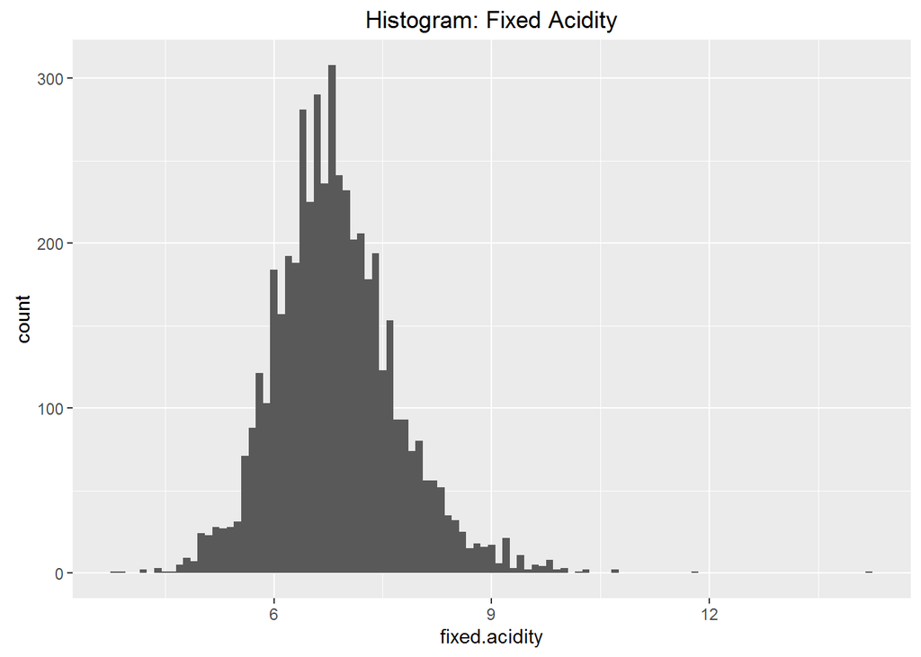

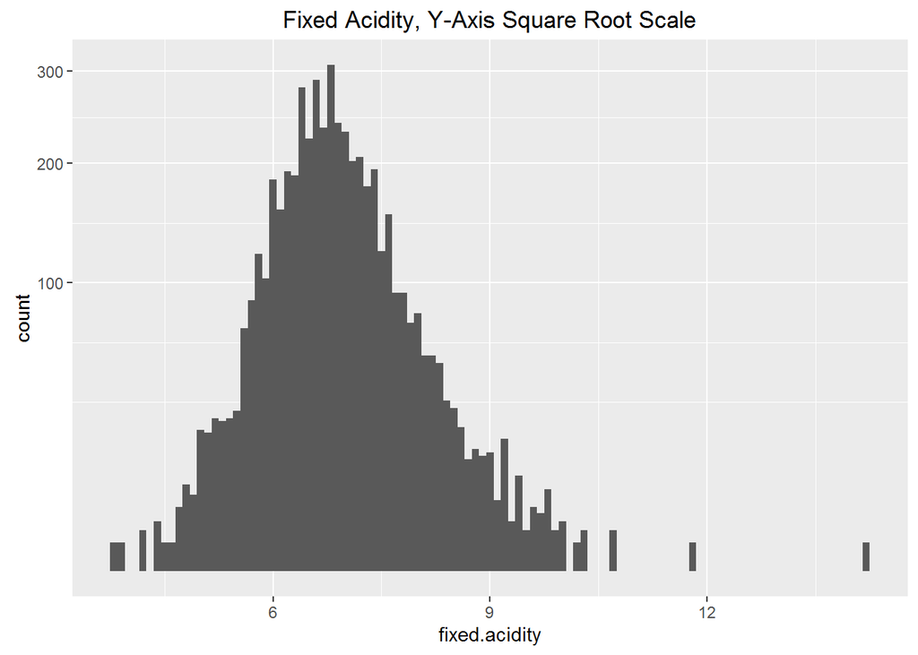

```
##    Min. 1st Qu.  Median    Mean 3rd Qu.    Max.
##   3.800   6.300   6.800   6.855   7.300  14.200
```

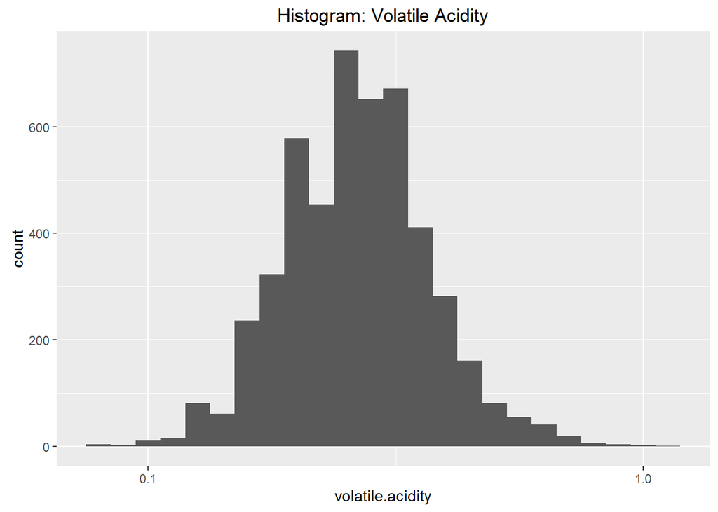

```
##    Min. 1st Qu.  Median    Mean 3rd Qu.    Max.
##  0.0800  0.2100  0.2600  0.2782  0.3200  1.1000
```

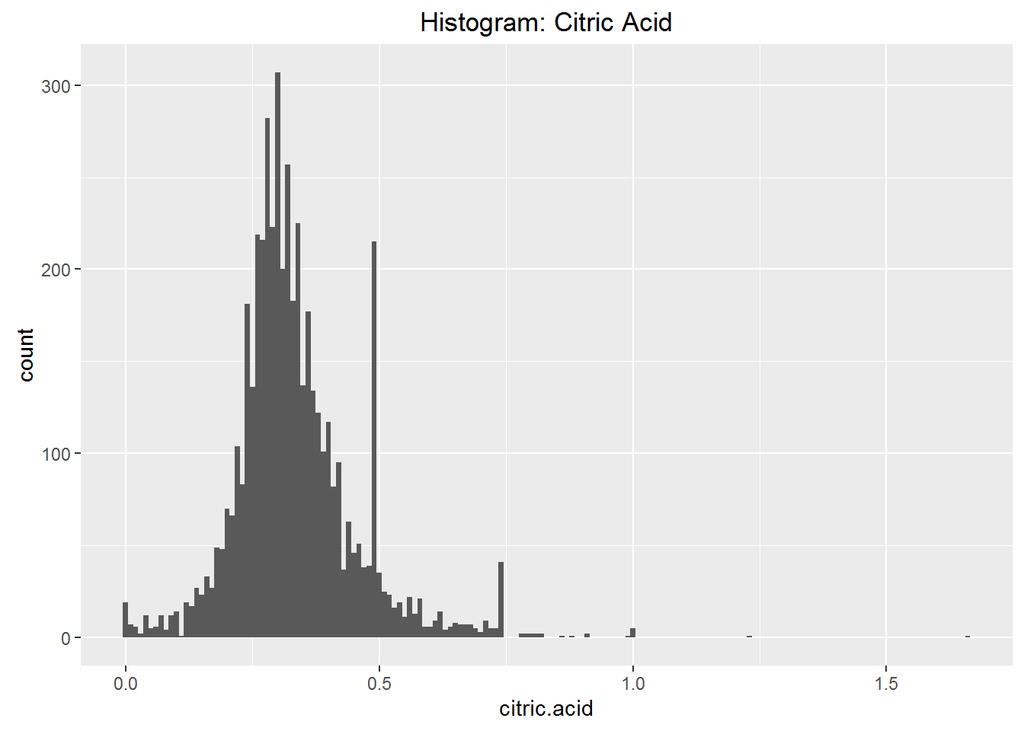

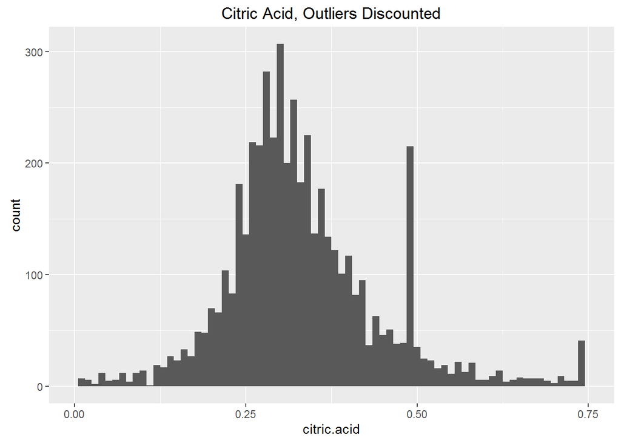

```
##    Min. 1st Qu.  Median    Mean 3rd Qu.    Max.
##  0.0000  0.2700  0.3200  0.3342  0.3900  1.6600
```

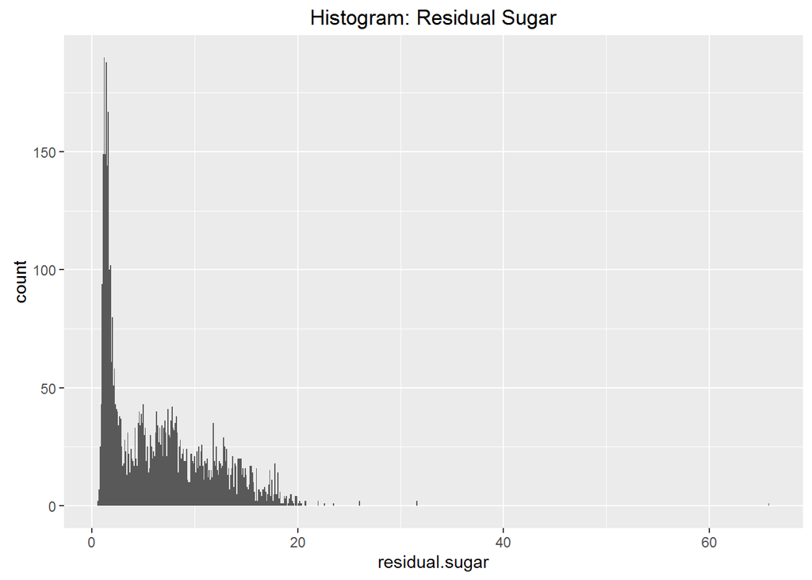

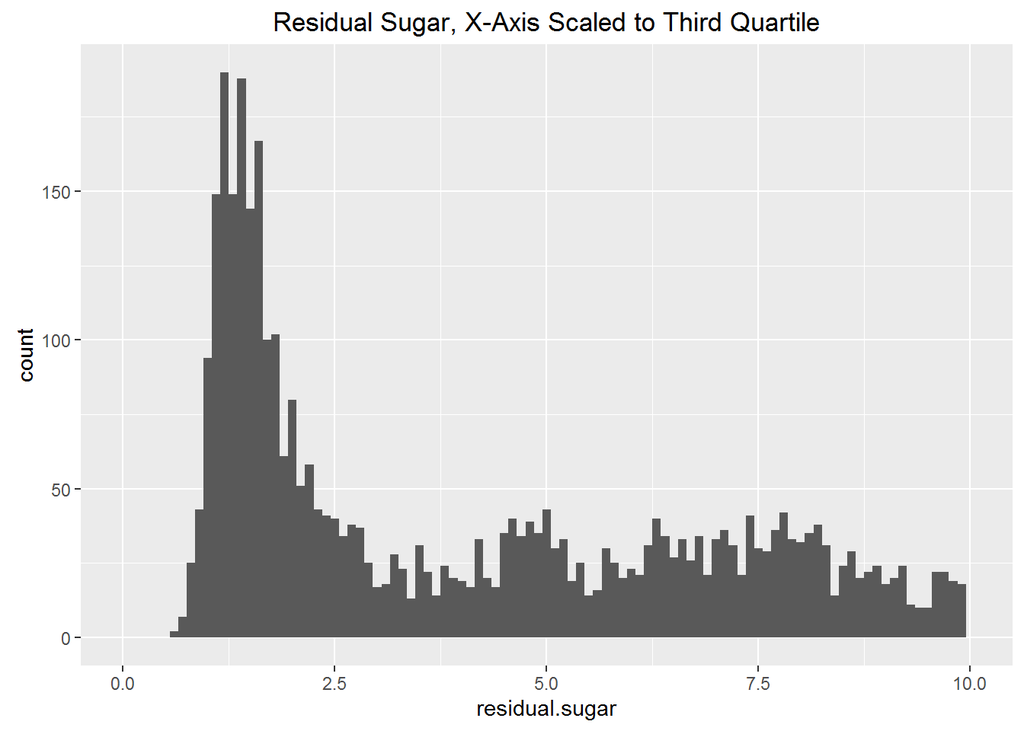

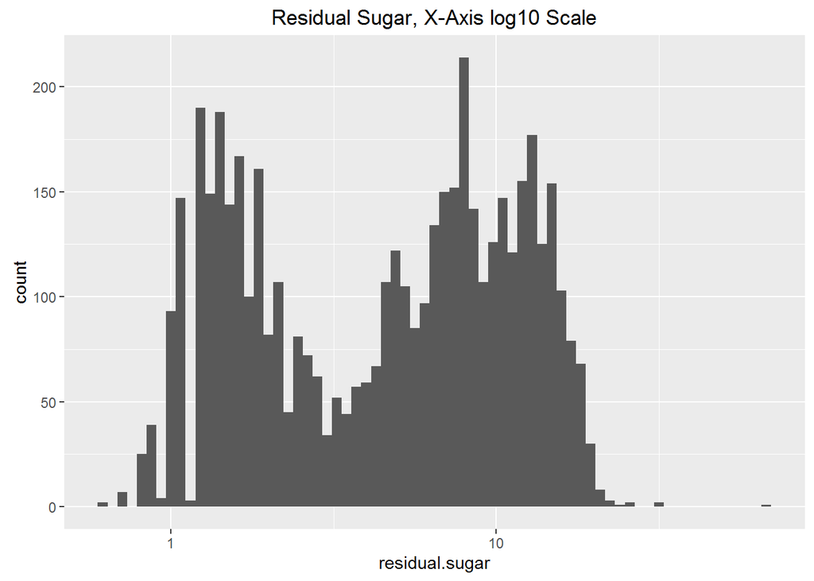

```
##    Min. 1st Qu.  Median    Mean 3rd Qu.    Max.
## -0.2218  0.2304  0.7160  0.6432  0.9956  1.8180
```

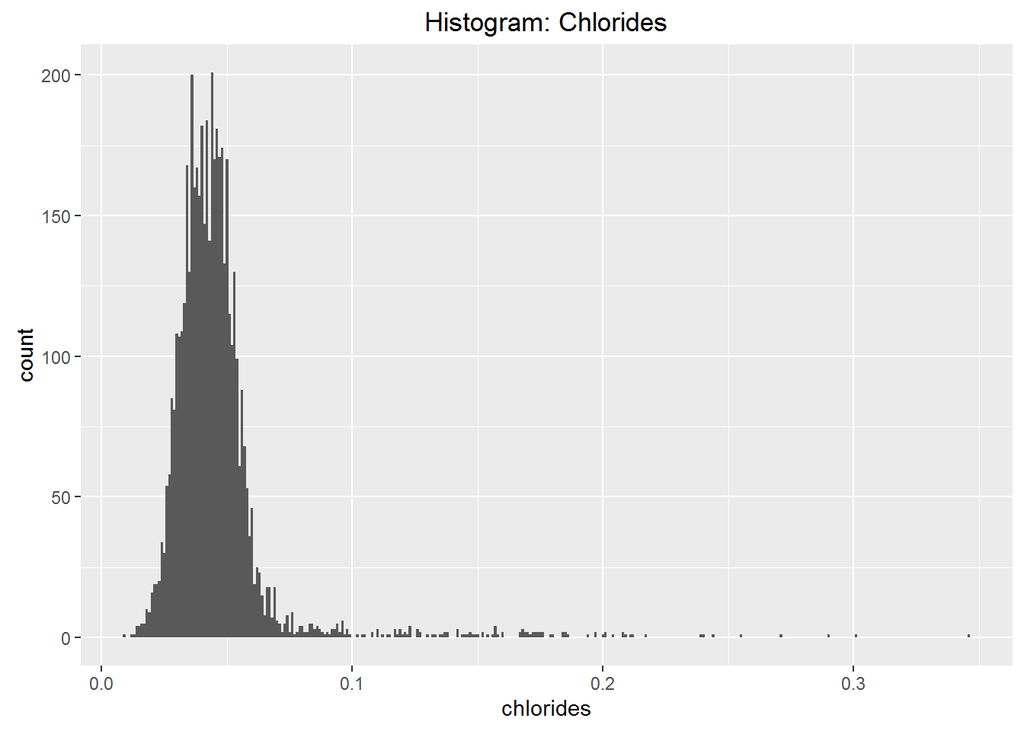

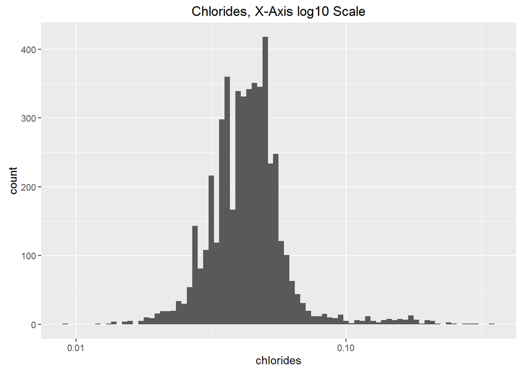

```
##    Min. 1st Qu.  Median    Mean 3rd Qu.    Max.
## 0.00900 0.03600 0.04300 0.04577 0.05000 0.34600
```

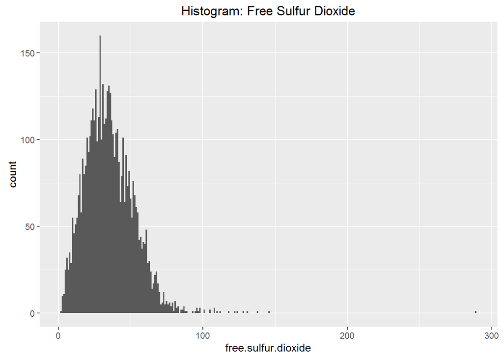

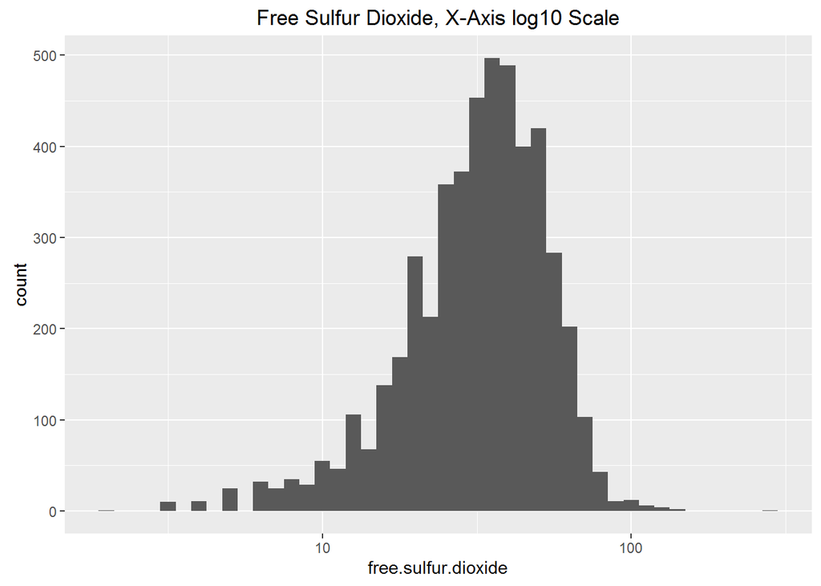

```
##    Min. 1st Qu.  Median    Mean 3rd Qu.    Max.
##    2.00   23.00   34.00   35.31   46.00  289.00
```

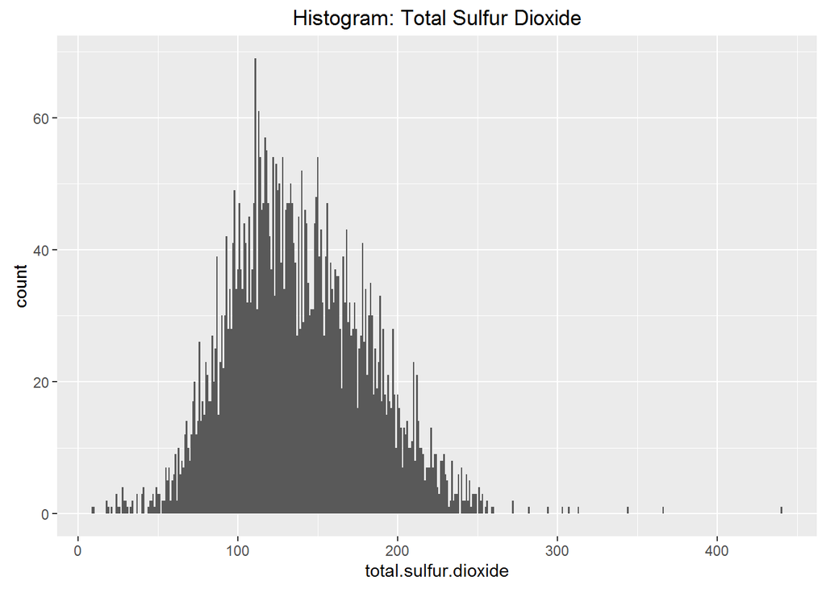

```
##    Min. 1st Qu.  Median    Mean 3rd Qu.    Max.
##     9.0   108.0   134.0   138.4   167.0   440.0
```

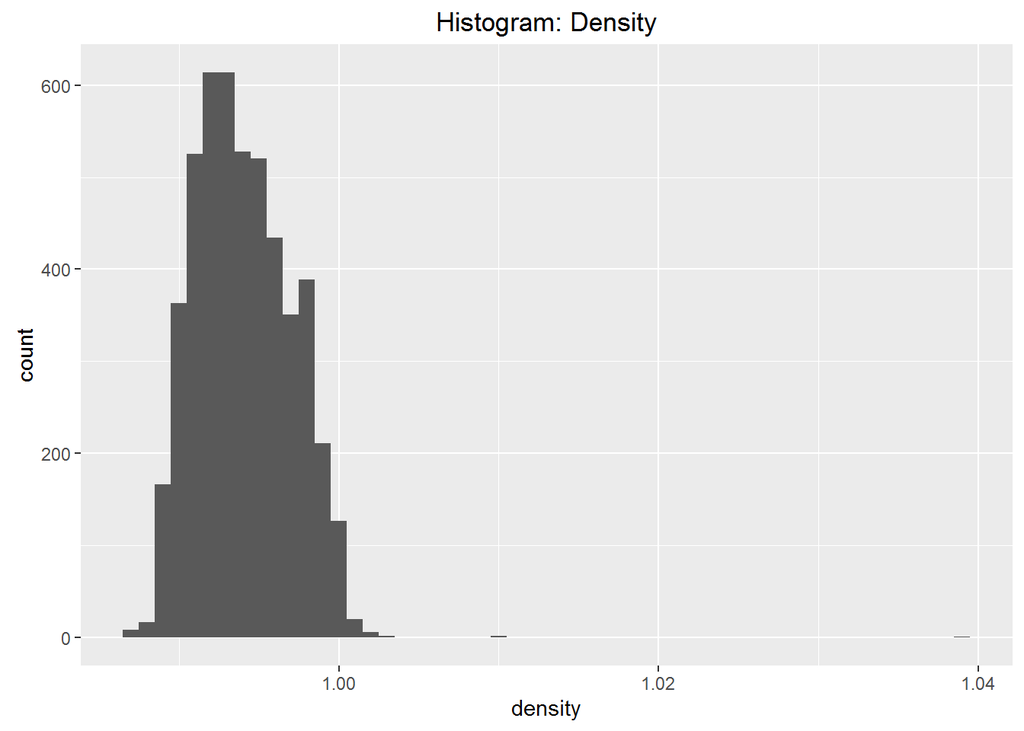

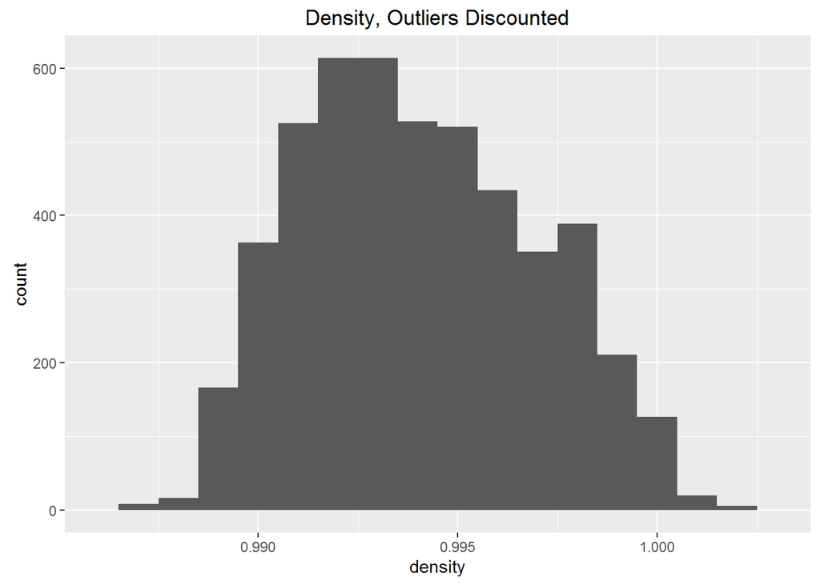

```
##    Min. 1st Qu.  Median    Mean 3rd Qu.    Max.
##  0.9871  0.9917  0.9937  0.9940  0.9961  1.0390
```

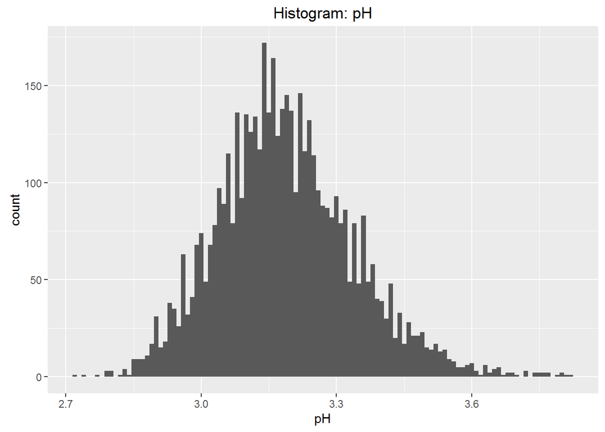

```
##    Min. 1st Qu.  Median    Mean 3rd Qu.    Max.
##   2.720   3.090   3.180   3.188   3.280   3.820
```

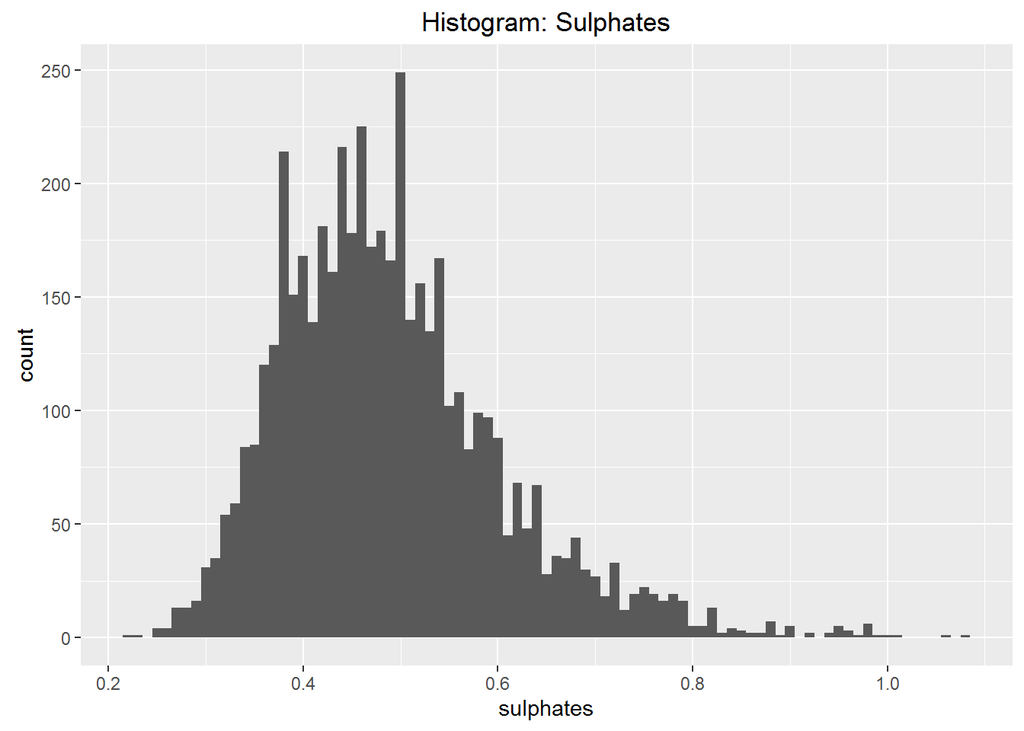

```
##    Min. 1st Qu.  Median    Mean 3rd Qu.    Max.
##  0.2200  0.4100  0.4700  0.4898  0.5500  1.0800
```

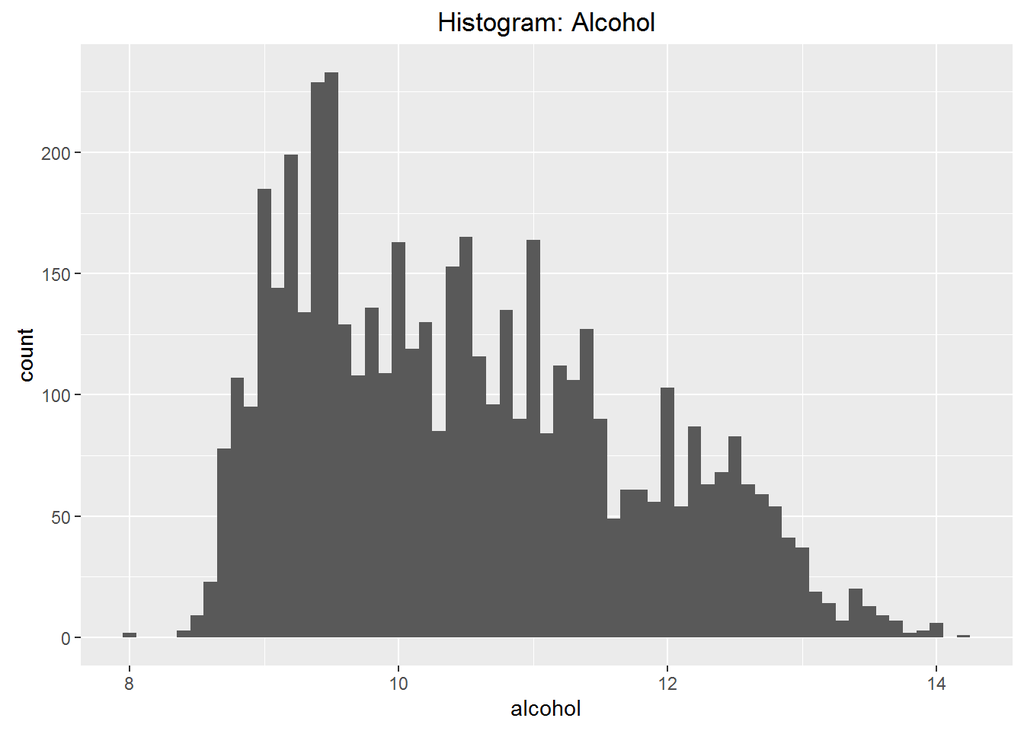

```
##    Min. 1st Qu.  Median    Mean 3rd Qu.    Max.
##    8.00    9.50   10.40   10.51   11.40   14.20
```

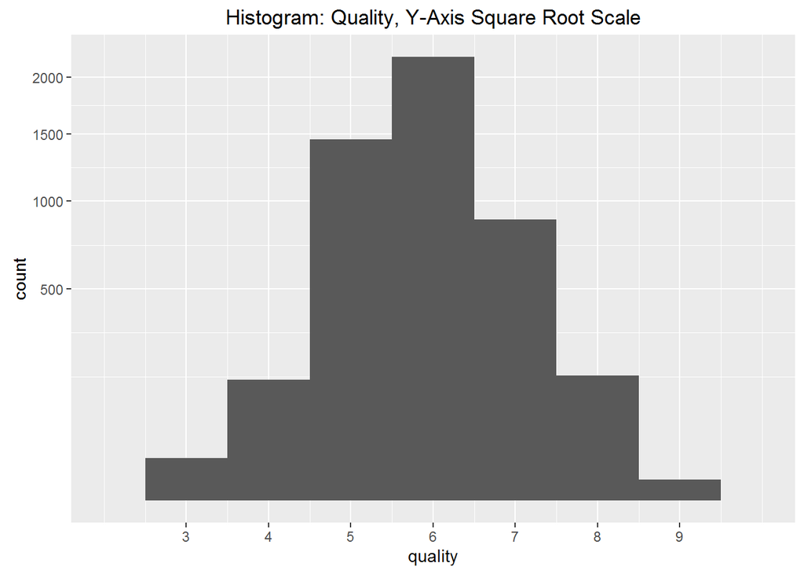

```
##    Min. 1st Qu.  Median    Mean 3rd Qu.    Max.
##   3.000   5.000   6.000   5.878   6.000   9.000
```

### Initial Observations

While the summaries and histograms show that our data is very regular, there seems to be a slight issue with inter-value noise. Even though our histograms are tailored to the significant figures used in the study, we see quite a bit of variation from bin to bin.

Our histogram for ‘sulphates’ is an excellent example.

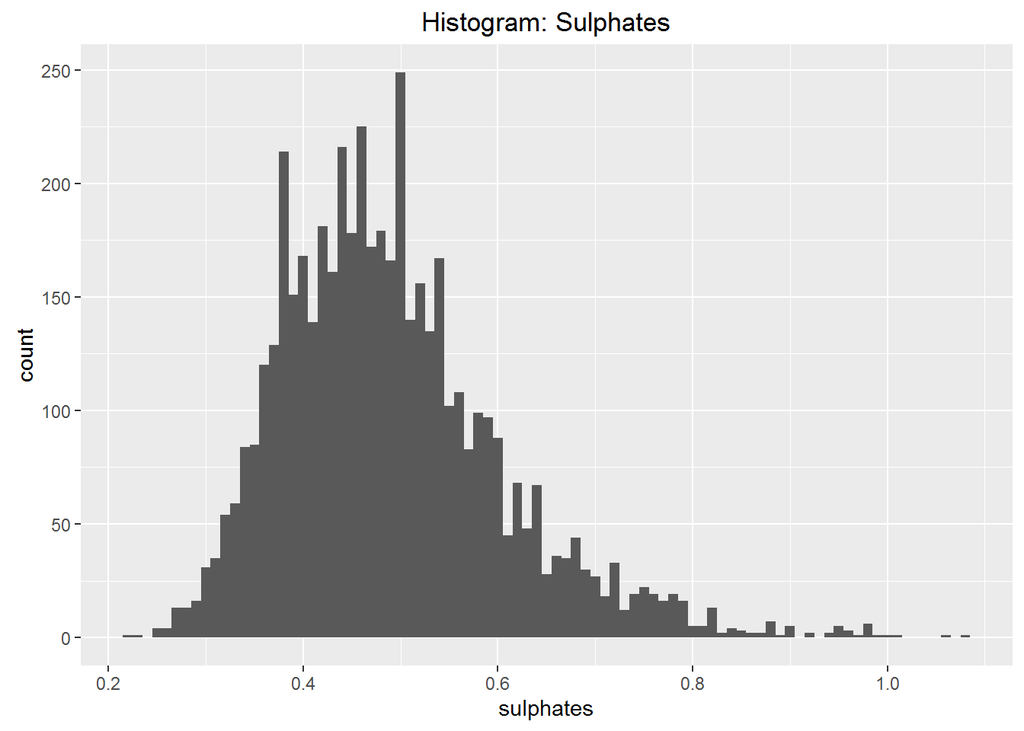

There is a clear normal distribution to values in the ‘sulphates’ variable, but fairly severe variation between observation value counts. This characteristic appears in many of our plots. I believe that these vast count swings are due to rounding error. As such, so long as it is consistent, it ought not have any malicious effects on the data or our analysis.

```
##    Min. 1st Qu.  Median    Mean 3rd Qu.    Max.
##   3.000   5.000   6.000   5.878   6.000   9.000
```

As such, it may be prudent to separate our wines by quality categorically into buckets, like so:

- Quality 3-4 = ‘Poor’
- Quality 5-6 = ‘Fair’
- Quality 7-9 = ‘Good’

As we continue our analysis into bivariate and multivariate analyses, I believe this categorization will aid in our understanding of what characteristics contribute to a wine’s quality.

```
## Poor Fair Good
##  183 3655 1060
```

# Bivariate Exploration & Analysis

### Pearson’s R - Bivariate Tests for Correlation

```
##                      fixed.acidity volatile.acidity  citric.acid
## fixed.acidity           1.00000000      -0.02269729  0.289180698
## volatile.acidity       -0.02269729       1.00000000 -0.149471811
## citric.acid             0.28918070      -0.14947181  1.000000000
## residual.sugar          0.08902070       0.06428606  0.094211624
## chlorides               0.02308564       0.07051157  0.114364448
## free.sulfur.dioxide    -0.04939586      -0.09701194  0.094077221
## total.sulfur.dioxide    0.09106976       0.08926050  0.121130798
## density                 0.26533101       0.02711385  0.149502571
## pH                     -0.42585829      -0.03191537 -0.163748211
## sulphates              -0.01714299      -0.03572815  0.062330940
## alcohol                -0.12088112       0.06771794 -0.075728730
## quality                -0.11366283      -0.19472297 -0.009209091
##                      residual.sugar   chlorides free.sulfur.dioxide
## fixed.acidity            0.08902070  0.02308564       -0.0493958591
## volatile.acidity         0.06428606  0.07051157       -0.0970119393
## citric.acid              0.09421162  0.11436445        0.0940772210
## residual.sugar           1.00000000  0.08868454        0.2990983537
## chlorides                0.08868454  1.00000000        0.1013923521
## free.sulfur.dioxide      0.29909835  0.10139235        1.0000000000
## total.sulfur.dioxide     0.40143931  0.19891030        0.6155009650
## density                  0.83896645  0.25721132        0.2942104109
## pH                      -0.19413345 -0.09043946       -0.0006177961
## sulphates               -0.02666437  0.01676288        0.0592172458
## alcohol                 -0.45063122 -0.36018871       -0.2501039415
## quality                 -0.09757683 -0.20993441        0.0081580671
##                      total.sulfur.dioxide     density            pH
## fixed.acidity                 0.091069756  0.26533101 -0.4258582910
## volatile.acidity              0.089260504  0.02711385 -0.0319153683
## citric.acid                   0.121130798  0.14950257 -0.1637482114
## residual.sugar                0.401439311  0.83896645 -0.1941334540
## chlorides                     0.198910300  0.25721132 -0.0904394560
## free.sulfur.dioxide           0.615500965  0.29421041 -0.0006177961
## total.sulfur.dioxide          1.000000000  0.52988132  0.0023209718
## density                       0.529881324  1.00000000 -0.0935914935
## pH                            0.002320972 -0.09359149  1.0000000000
## sulphates                     0.134562367  0.07449315  0.1559514973
## alcohol                      -0.448892102 -0.78013762  0.1214320987
## quality                      -0.174737218 -0.30712331  0.0994272457
##                        sulphates     alcohol      quality
## fixed.acidity        -0.01714299 -0.12088112 -0.113662831
## volatile.acidity     -0.03572815  0.06771794 -0.194722969
## citric.acid           0.06233094 -0.07572873 -0.009209091
## residual.sugar       -0.02666437 -0.45063122 -0.097576829
## chlorides             0.01676288 -0.36018871 -0.209934411
## free.sulfur.dioxide   0.05921725 -0.25010394  0.008158067
## total.sulfur.dioxide  0.13456237 -0.44889210 -0.174737218
## density               0.07449315 -0.78013762 -0.307123313
## pH                    0.15595150  0.12143210  0.099427246
## sulphates             1.00000000 -0.01743277  0.053677877
## alcohol              -0.01743277  1.00000000  0.435574715
## quality               0.05367788  0.43557472  1.000000000
```

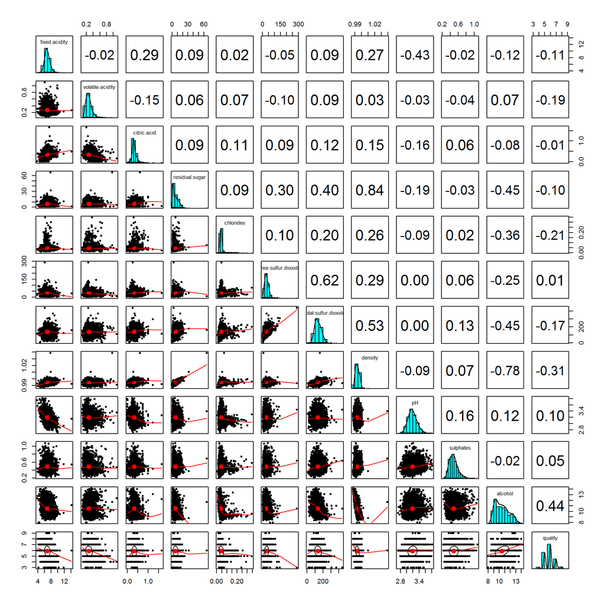

### Initial Findings

As we examine the correlations between our variables, we ought not be surprised at some very high correlations. Consider the following correlated variables:

- Residual Sugar, Alcohol, and Density

  I know from some brewing experience that the density (or specific gravity) of your wine or beer is a function of how much sugar is converted into alcohol by the yeast. Therefore, seeing a positive correlation coefficient of 0.84 between density and residual sugar and a negative correlation coefficient of -0.78 between density and alcohol is to be expected.
- Free Sulfur Dioxide and Total Sulfur Dioxide

  These variables are certainly linked. It may be useful to create a new variable of their ratio.

Nevertheless, at this initial bivariate stage of analysis, the most highly correlated variable for quality is alcohol. Obvious jokes aside, there may be many reasons for this - for example, lower levels of yeast activity resulting in higher residual sugar levels. It also seems likely that the perception of a wine’s quality is likely based in interaction effects between many variables - effects that will become more clear in our multivariate model.

### Sulfur Dioxide Ratio

Let’s create the ratio between Free Sulfur Dioxide and Total Sulfur Dioxide.

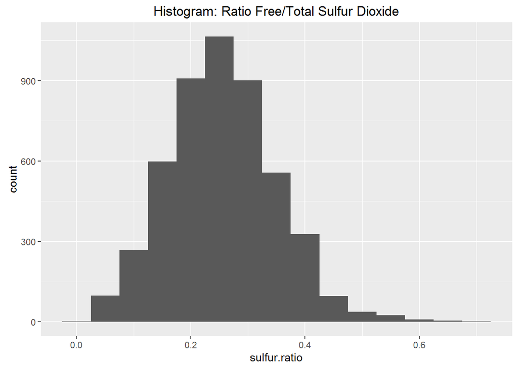

```
##    Min. 1st Qu.  Median    Mean 3rd Qu.    Max.
## 0.02362 0.19090 0.25370 0.25560 0.31580 0.71050
```

```
##
##  Pearson's product-moment correlation
##
## data:  wwines$sulfur.ratio and wwines$quality
## t = 14.076, df = 4896, p-value < 2.2e-16
## alternative hypothesis: true correlation is not equal to 0
## 95 percent confidence interval:
##  0.1701474 0.2239834
## sample estimates:
##       cor
## 0.1972141
```

### Quality, Rating, and Predictor Variables

A closer look at our quality-related scatterplots and boxplots is in order.

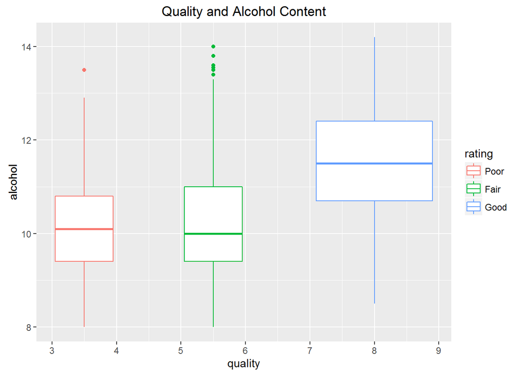

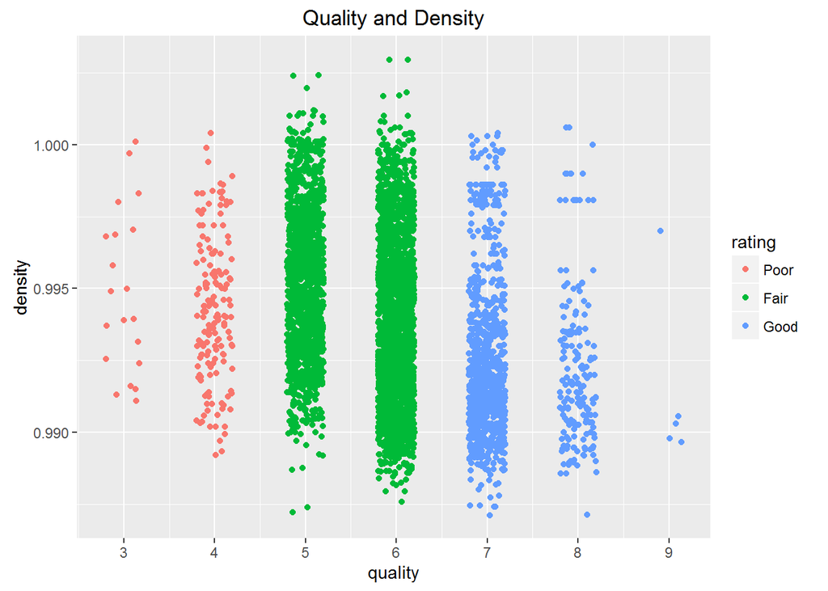

As the two individual independent variables with the greatest correlation coefficients, Alcohol and Density deserve special attention.

Our boxplot reveals that the alcohol contents for wines with Poor and Fair ratings are fairly similar, but Good wines have far greater levels of alcohol.

Looking at the density of values in our jittered scatterplot, we may observe that the negative correlation between density and quality is largely made between quality levels 5, 6, and 7. The densest grouping of values within each quality level really reflects our correlation finding, and you can see the pattern a little bit in our less-represented categories as well - quality level 8, for example, has a very similar distribution of density to quality level 4, except that there are far fewer values above 0.996. Our few, most highly rated wines (quality 9) are mostly clustered around 0.990.

# Final Plots & Summary

### Linear Model

```
##
## Calls:
## m1: lm(formula = quality ~ alcohol, data = wwines)
## m2: lm(formula = quality ~ density, data = wwines)
## m3: lm(formula = quality ~ alcohol + density + sulphates + chlorides,
##     data = wwines)
## m4: lm(formula = quality ~ fixed.acidity + volatile.acidity + citric.acid +
##     residual.sugar + chlorides + free.sulfur.dioxide + total.sulfur.dioxide +
##     density + pH + sulphates + alcohol + sulfur.ratio, data = wwines)
##
## ========================================================================
##                            m1          m2          m3          m4
## ------------------------------------------------------------------------
##   (Intercept)            2.582***   96.277***  -18.665**    143.337***
##                         (0.098)     (4.003)     (6.175)     (18.628)
##   alcohol                0.313***                0.339***     0.189***
##                         (0.009)                 (0.015)      (0.024)
##   density                          -90.942***   21.000***  -144.195***
##                                     (4.027)     (6.091)     (18.893)
##   sulphates                                      0.447***     0.603***
##                                                 (0.100)      (0.099)
##   chlorides                                     -2.420***    -0.386
##                                                 (0.557)      (0.541)
##   fixed.acidity                                               0.065**
##                                                              (0.021)
##   volatile.acidity                                           -1.800***
##                                                              (0.113)
##   citric.acid                                                 0.040
##                                                              (0.095)
##   residual.sugar                                              0.079***
##                                                              (0.007)
##   free.sulfur.dioxide                                        -0.020***
##                                                              (0.002)
##   total.sulfur.dioxide                                        0.005***
##                                                              (0.001)
##   pH                                                          0.681***
##                                                              (0.104)
##   sulfur.ratio                                                3.583***
##                                                              (0.357)
## ------------------------------------------------------------------------
##   R-squared                 0.190      0.094       0.199        0.296
##   adj. R-squared            0.190      0.094       0.198        0.295
##   sigma                     0.797      0.843       0.793        0.744
##   F                      1146.395    509.911     303.407      171.451
##   p                         0.000      0.000       0.000        0.000
##   Log-likelihood        -5839.391  -6111.983   -5811.993    -5493.840
##   Deviance               3112.257   3478.689    3077.633     2702.695
##   AIC                   11684.782  12229.967   11635.987    11015.681
##   BIC                   11704.272  12249.456   11674.966    11106.633
##   N                      4898       4898        4898         4898
## ========================================================================
```

Our final linear model is pretty fascinating. Including every independent variable in the model, including our added sulfur ratio variable, the R-squared score for explaining variation only reaches 0.296. Within the linear model, a few variables are not even significant. Interestingly, chlorides appears significant in our third model, but its significance disappears in the fourth model - the introduction of other, better descriptors (notably volatile acidity) stole its thunder. Likewise, our created Sulfur Ratio variable is significant and has far greater effects than either Free or Total Sulfur Dioxide.

### Final Plots and Summary

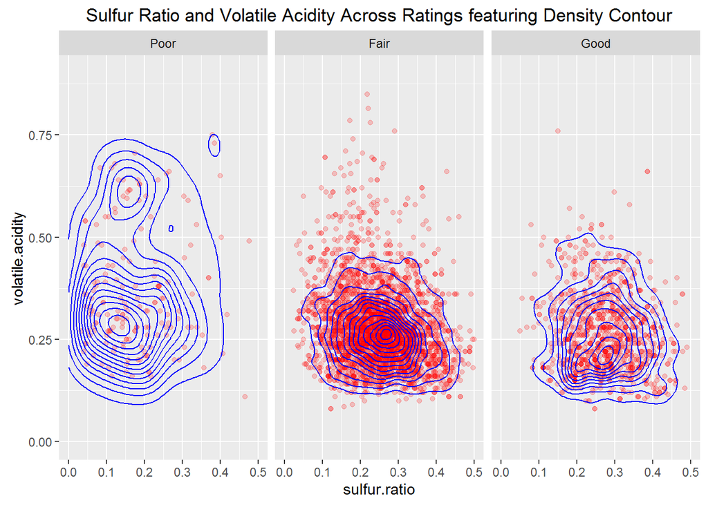

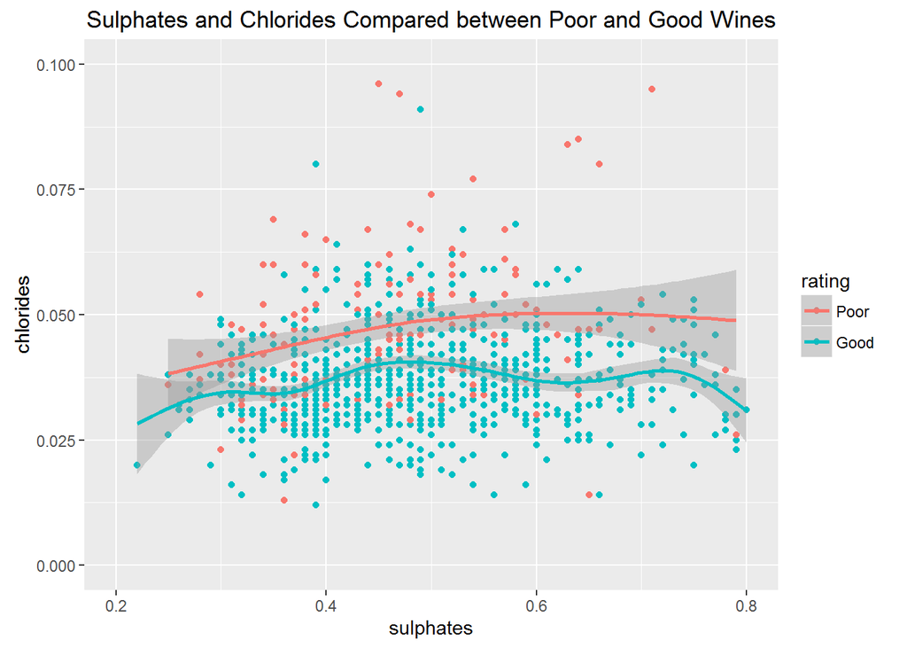

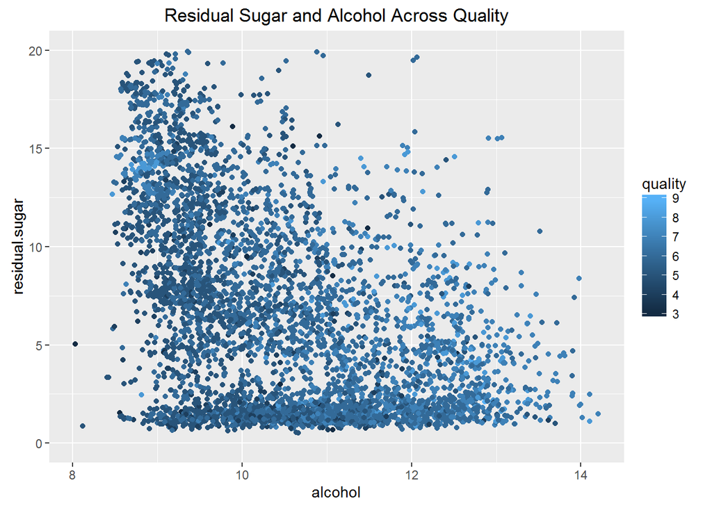

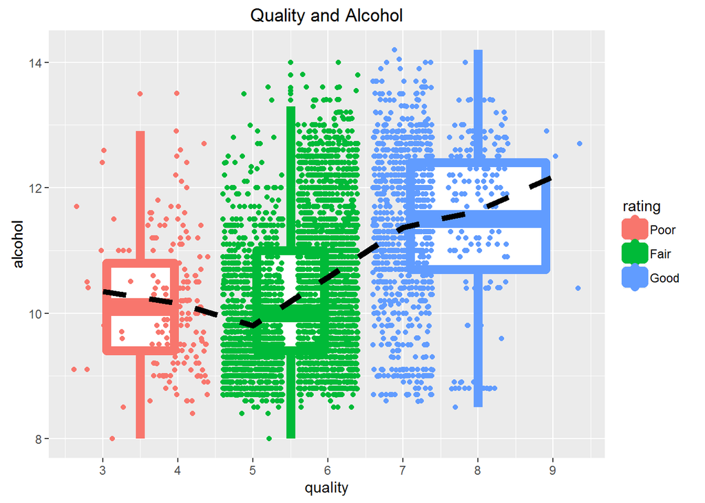

Our final plots seek to take the conclusions of our linear model and make them more tangible.

The first plot demonstrates the subtle effects of volatile acidity (the acidity category with greatest effect on the dependent variable) and sulfur ratio. Density contours aid in seeing the distribution of data points. In particular, it is apparent that volatile acidity above 0.5 is represented proportionally well only among ‘Poor’ wines. We may also see that the ‘nuclei’ of the density contours tend, across ratings, to increase in sulfur ratio and decrease in volatile acidity.

The second plot is a lesson in spurious correlation - I had created this plot before running the fourth model that includes every independent variable. The smoothers help us to see the difference in covariation between sulphates and chlorides between wines of Poor and Good quality, with the difference in means between the two ratings along the y-axis seeming pretty substantial. However, in light of the full model, chlorides failed to be a statistically significant predicting variable.

The third plot shows another side of the predictive quality of alcohol content. The whole of the graph shows a clear right-triangular shape - as we explored in our panel pairs, there is a solid negative correlation between residual sugar and alcohol content. This plot also shows some of the internal structure of the triangle by coloring points by their quality scores. Along the left, vertical edge of the triangle, most of the points are a dark blue, indicating a low score in quality. However, as alcohol increases, tolerance for residual sugar seems to increase - even points high in the Y-axis become lighter as we travel to the right on the X-axis.

However, our linear model demonstrates one thing for certain - the majority of the predictive power of our independent variables comes from the alcohol variable. In our final plot, we may pick out a few different measures of the effect of alcohol on quality. 1. The effect isn’t perfectly linear. Our dashed black line shows the means of alcoholic content across quality. While it gently dips between scores 3 and 5, it slopes considerably and consistently positive between 5 and 9. 2. Our boxplots represent the spread of alcohol values for rating categories of Poor, Fair, and Good. The mean and quartiles for white wines with a Good rating sit far above the means and quartiles of Poor and Fair wines, which appear substantially similiar. 3. The whiskers representing the range of our rating data do progress in a positive direction as quality increases, but high-bound outliers exists for both Poor and Fair wines. This casts some doubt on our independent variable’s predictive quality - higher alcohol content does seem to cause tendency toward a higher score for quality, but it seems to be a necessary condition rather than a sufficient condition. With an R-squared of only .2, it seems likely that alcohol interacts with other unmeasured factors that may better determine a white wine’s rating.

### Reflection

While this study has proven to be interesting in a number of ways, I would say that we have failed to create a strong predictive model for our dependent variable, quality. Even taking every measurement of every variable into consideration, our error term in the linear model still explains more than seventy percent of its total variation.

It must not be forgotten that the vast majority of this data set is scored either 5 or 6 in quality. Linear models benefit from having dependent variables that cover a wider array of values or have a finer degree of differentiation. In this case, more than two-thirds of our five thousand data points occupy the Fair category alone. The paucity of variation in our dependent variable likely contributes to the difficulty of fitting a good model.

What other variables may have aided us in understanding the quality of white wines? I may be speaking from ignorance, being something of a wine troglodyte, but it concerns me that we have no control for variation in scoring between different experts. It may be that wine experts actually have very tightly controlled and objective methods for rating white wines, but a categorical variable for which expert rated which wine is critical, even if it only confirms their expert rigor. Control over the most subjective part of our study would give me much greater faith in our results, even if our error term stayed just as high, because we could then faithfully chalk it up to the mysterious ‘je ne sais quoi’ of wine rather than questioning whether our quality ratings were influenced by personal preferences.